# Boxplots_ggplot2

Justin Strate

I would like to cover the basics of boxplots in ggplot2 here. If you would like to use the base R functions see the page on scatterplots in ggplot2. Let’s use the iris data set again. If you haven’t had a decent introduction to ggplot2 I highly recommend you check out scatterplots first,which should give you a good introduction to the syntax of ggplot2. Although it covers scatter plots, you’ll find that many of the features overlap.

First, let’s load the libraries and the data we need.

```r
library(ggplot2)
library(ggthemes)

data("iris")
```

We’ll create a basic, vertical boxplot of Sepal.Width. Since this is a vertical boxplot of all the flowers’ sepal width, we don’t need to do anything with the x-axis. So, we will simply set it to 1. Later, we’ll change it to something not so trivial.

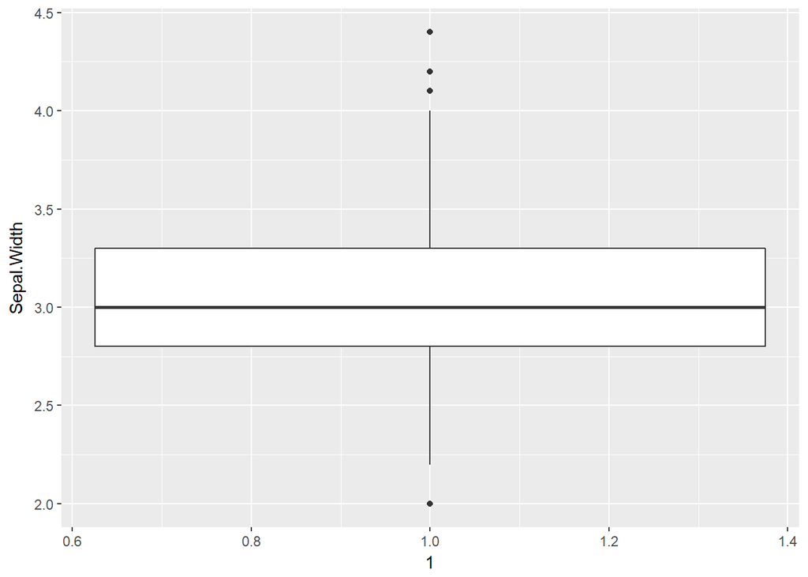

```r
#A Basic boxplot of Sepal.Width
(box1 <- ggplot(data = iris, mapping = aes(1, Sepal.Width))+
          geom_boxplot())
```

The x-axis is not only ugly but uninformative; so let’s clear the x-axis.

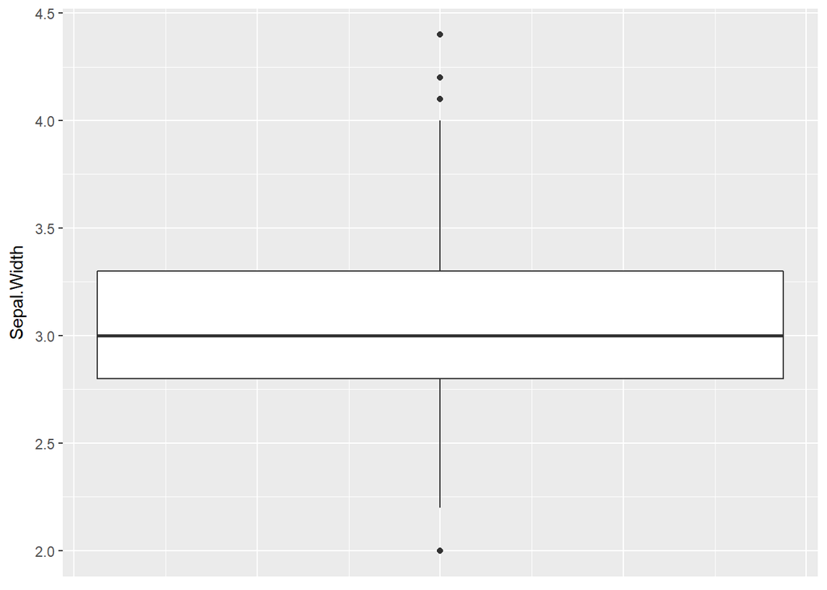

```r
box1 +
      theme(axis.title.x=element_blank(),
      axis.text.x=element_blank(),
      axis.ticks.x=element_blank())
```

Let’s make a horizontal boxplot, and add a title and theme. If you want more information on themes check out the page on scatter plots. There you can see a lot more themes and how to overcome some of the problems some themes can introduce.

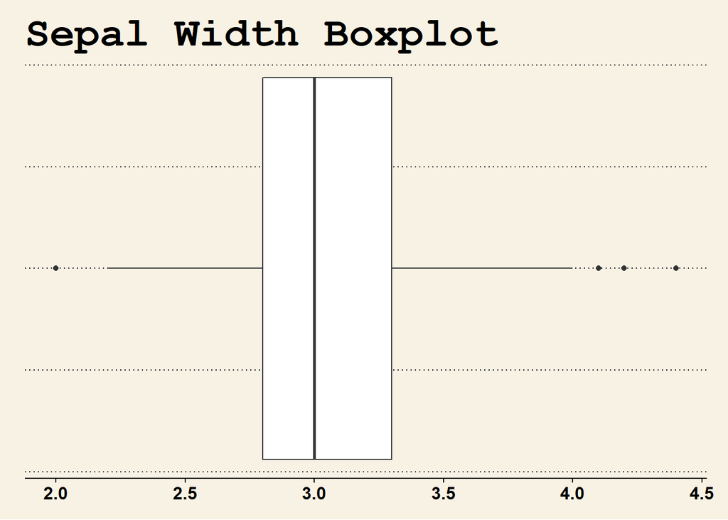

```r
#Make a horizontal boxplot and add a title and a theme
box1 +
  theme_wsj()+
  coord_flip()+
  #now we need to make the y-axis blank
  theme(axis.title.y=element_blank(),
        axis.text.y=element_blank(),
        axis.ticks.y=element_blank())+
  ggtitle('Sepal Width Boxplot')
```

Now, suppose we want to compare sepal widths for the different species of flower in the data set. It’s here where boxplots in ggplot2 are more intuitive than the base R functions.

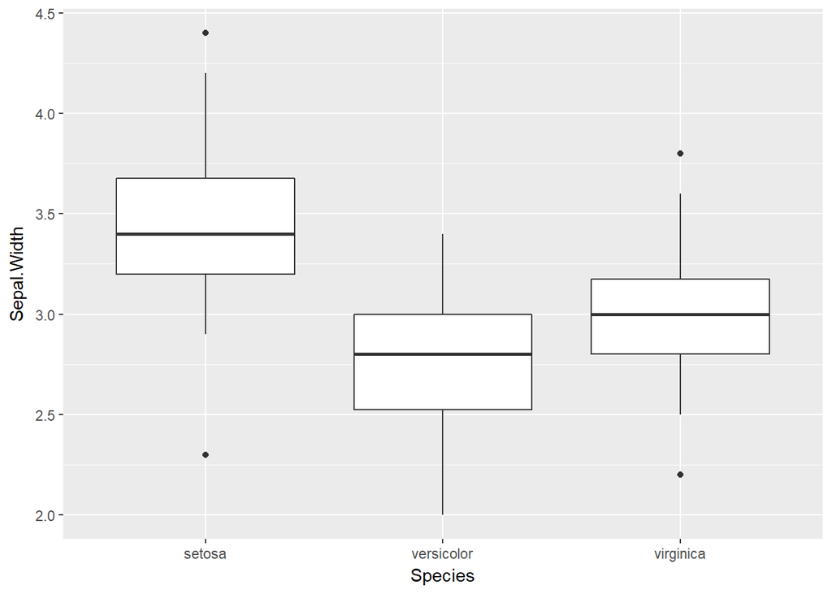

```r
#Let's make a boxplot for each different species
(box2 <- ggplot(data = iris, mapping = aes(Species, Sepal.Width))+
          geom_boxplot())
```

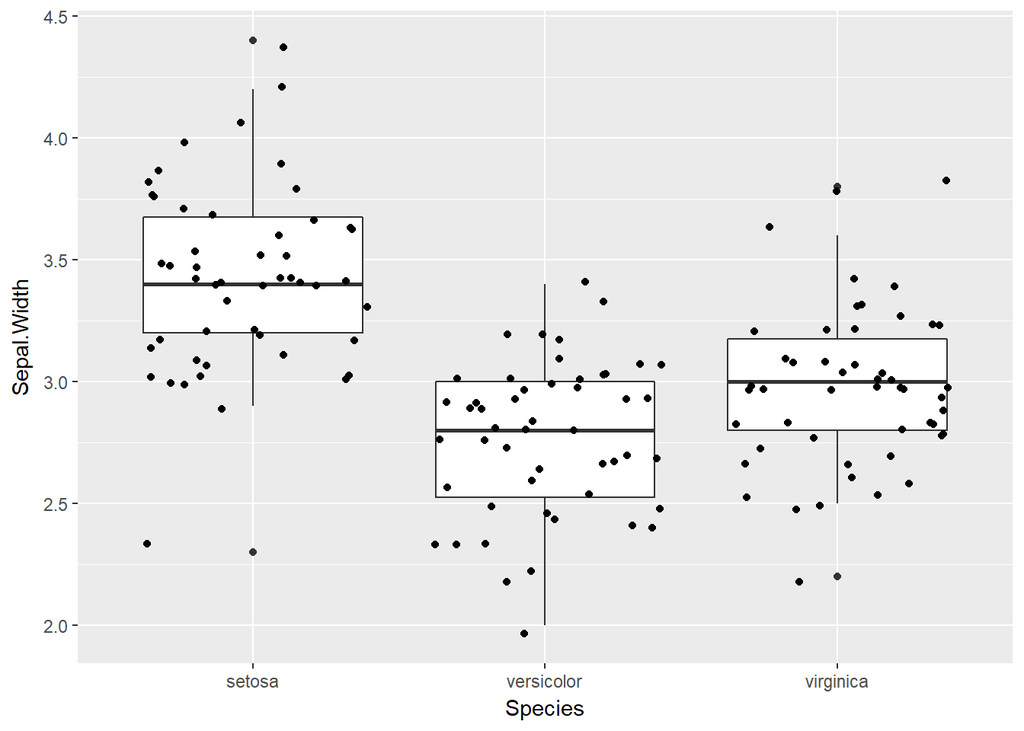

```r
box2 +
  geom_jitter()
```

Let’s make a notch boxplot, and let’s give each boxplot a different color. The narrowing of the notch provides information about the medians. If these notches do not overlap this provides statistical evidence against equal medians.

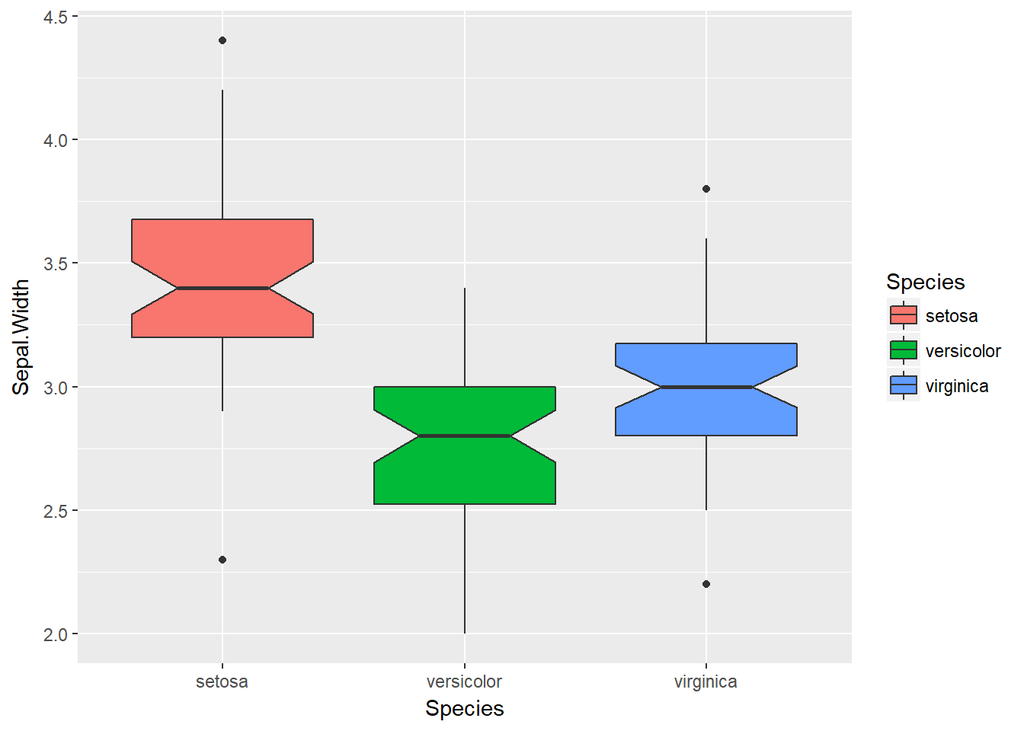

```r
ggplot(data = iris, mapping = aes(Species, Sepal.Width))+
          geom_boxplot(mapping = aes(fill=Species), notch = TRUE)
```

We can also make the color of the outliers different. For example, let’s change it to red.

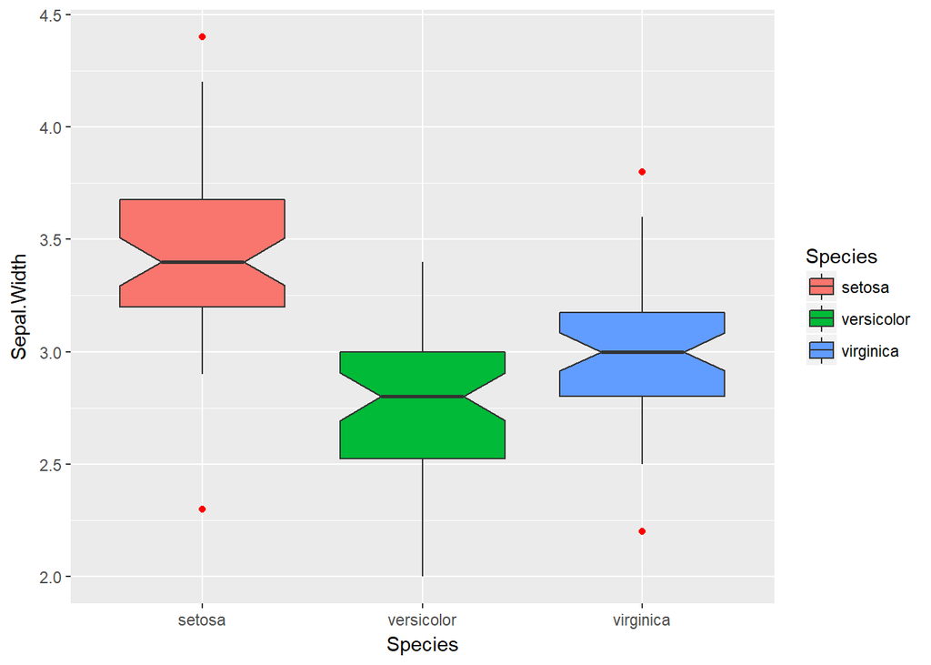

```r
(box3 <- ggplot(data = iris, mapping = aes(Species, Sepal.Width))+
  geom_boxplot(mapping = aes(fill=Species), notch = TRUE, outlier.colour = 'red'))
```

We can incorporate another variable, sepal length. We’ll use the the geom_jitter function to call the points. Then we will color them by Sepal.Length.

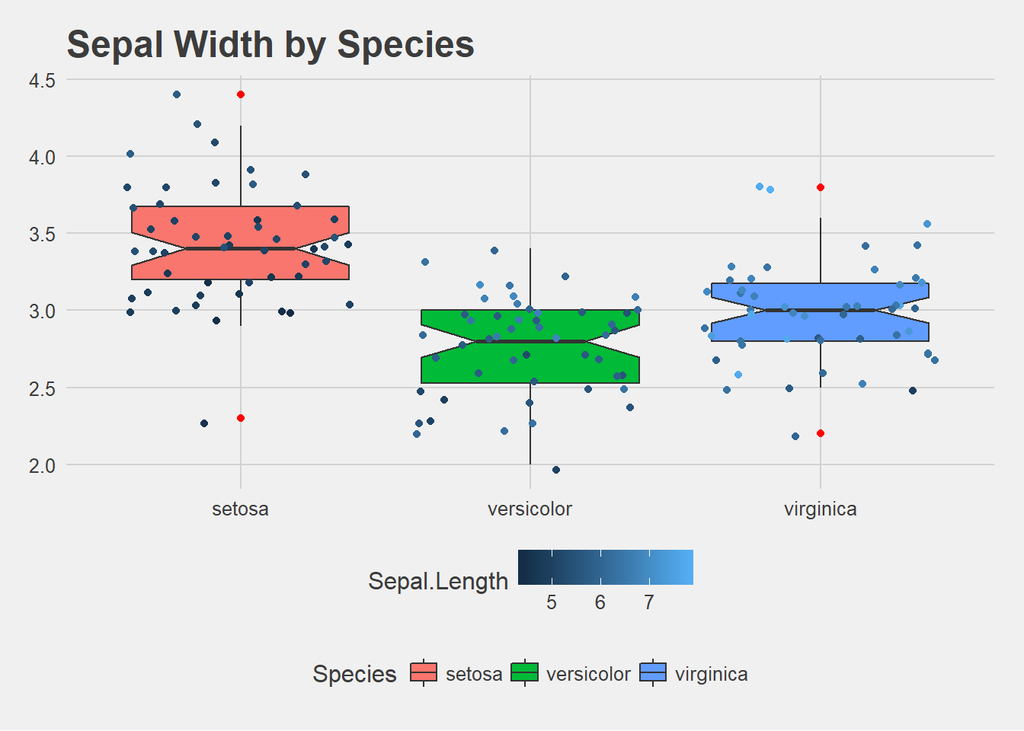

```r
box3 +
  geom_jitter(mapping = aes(colour=Sepal.Length))+
  ggtitle('Sepal Width by Species')+
  theme_fivethirtyeight()
```

As you see, the setosa species tends to have lower sepal lengths, despite having longer sepal widths on average.